# ACT REPORT

### Over 50% of Tweets come from one source?

Majority of the tweets are sent using Twitter for iPhones followed by the Twitter Web Client then the least used source being the TweetDeck

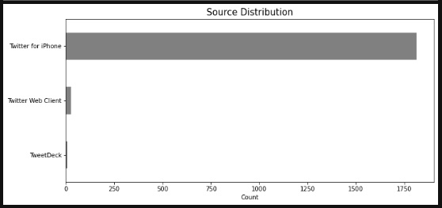

With further drilldown, we can see that though the tweets from the Twitter Web Client aren't as much as the ones from Twitter for iPhone, the amount of retweets on the Web Client is the highest compared to the remaining two sources.  
But the Likes are higher on Twitter for iPhone compared to the other two sources. This might be biased because majority of the tweets come from the Twitter for iPhone.

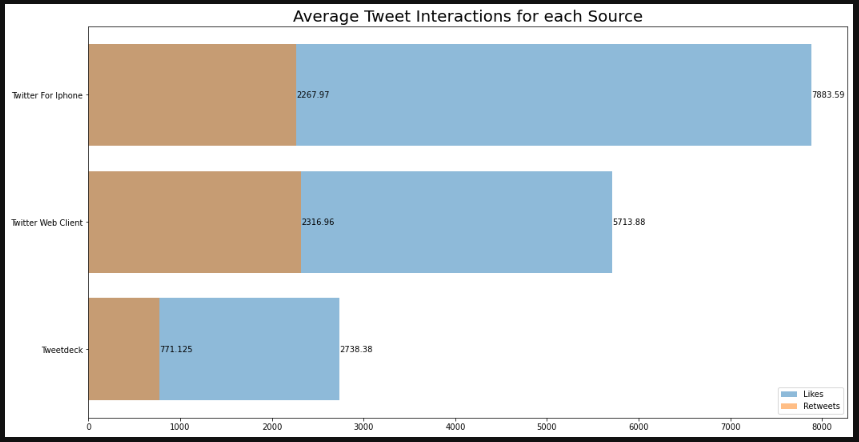

More on the Likes and Retweets, There is a positive correlation between the number of likes (favorite_counts) and retweets (retweets_counts).  
Which means that the posts that get more retweets will be visible to more people which in turn results to more likes for that post.

[figure not shown]

The dog ratings are skewed to the left which implies that majority of the ratings fall between 10 and 14.

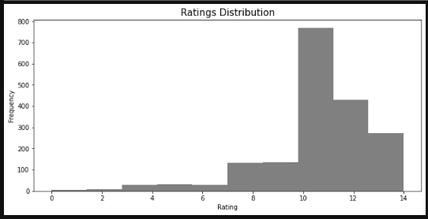

Aside the massive number of unknown dog names, Oliver, Charlie and Cooper are the three most populous dog names with 10 dogs answering each name.  
On the opposite side of the spectrum, there are 689 dog names that are unique to just one dog.

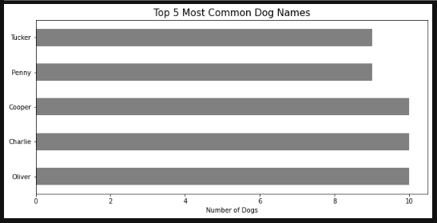

There are over 300 different breeds of dogs in this dataset but of these breads are more common than others. So we would be checking out the Top 5 most common dog breeds according to our dataset.  
With 85 dogs being Labrador Retrievers, this breed has turned out to be the most common dog breed in this dataset and coming immediately after is the Pemboke with 84 dogs, while we have other breeds like Chihuahua, Pug and Chow in the top 5 breeds.  
Regardless, all the breeds in this dataset are all amazing and beautiful.

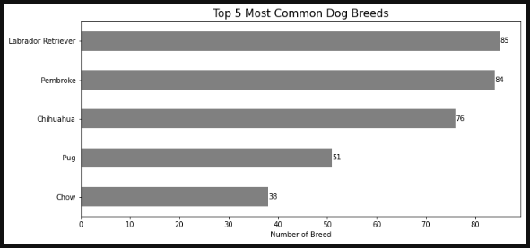